# Analyzing Reaction Time: Does Gender or Handedness Matter?

### Introduction

Reaction time plays a critical role in daily activities such as sports, driving, and gaming. The ability to respond quickly to external stimuli can often be the difference between success and failure, or even safety and danger. This study explores whether gender and handedness influence reaction time and whether there is an interaction effect between the two. To do this, I used data from the Census at School survey—a project that collects real-world data from students to help them learn statistics.

The statistical tool of choice is a **two-way ANOVA** (Analysis of Variance). This test helps determine if there are significant differences in reaction time based on gender, handedness, or the combination of both. Three hypotheses were tested:

1. **Gender Effect:** Do males and females have different reaction times?
2. **Handedness Effect:** Do left-handed and right-handed individuals have different reaction times?
3. **Interaction Effect:** Does the combination of gender and handedness influence reaction time?

### Data Preparation

```r
library(mosaic)
library(DT)
library(pander)
library(car)
library(tidyverse)

# Load the data
HSS <- read_csv("~/Statistics Notebook Github/Data/HighSchoolSeniors.csv")

# Clean the data
HSS2 <- HSS %>%
  filter(!is.na(Reaction_time),
         !is.na(Gender),
         !is.na(Handed)) %>%
  filter(Reaction_time < 1.0) %>%
  select(Gender, Reaction_time, Handed)

# Ensure Gender and Handed are factors
HSS2 <- HSS2 %>%
  mutate(Gender = as.factor(Gender),
         Handed = as.factor(Handed))

View(HSS2)
```

### Hypothesis #1: Gender Effect

#### Hypotheses

$$H_0: \mu_{maleReactionTime} = \mu_{femaleReactionTime}$$
$$H_a: \mu_{maleReactionTime} \neq \mu_{femaleReactionTime}$$

#### Summary Statistics

```r
gender_summary <- HSS2 %>%
  group_by(Gender) %>%
  summarise(
    Min = min(Reaction_time, na.rm = TRUE),
    Q1 = quantile(Reaction_time, 0.25, na.rm = TRUE),
    Median = median(Reaction_time, na.rm = TRUE),
    Q3 = quantile(Reaction_time, 0.75, na.rm = TRUE),
    Max = max(Reaction_time, na.rm = TRUE)
  )
pander(gender_summary)
```

| Gender | Min | Q1 | Median | Q3 | Max |
| --- | --- | --- | --- | --- | --- |
| Female | 0.168 | 0.3615 | 0.427 | 0.4925 | 0.995 |
| Male | 0.01 | 0.31 | 0.355 | 0.418 | 0.89 |

#### Visualization

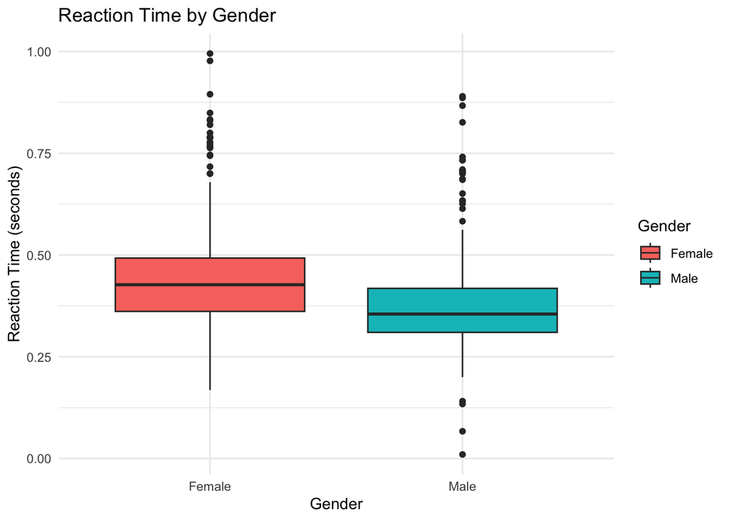

```r
ggplot(HSS2, aes(x = Gender, y = Reaction_time, fill = Gender)) +
  geom_boxplot() +
  labs(title = "Reaction Time by Gender", x = "Gender", y = "Reaction Time (seconds)") +
  theme_minimal()
```

### Hypothesis #1: Gender Effect

The first hypothesis aimed to determine whether there is a significant difference in reaction time between males and females. The summary statistics indicate that females have a slightly higher median reaction time of **0.427 seconds** compared to **0.355 seconds** for males. The interquartile range (IQR), representing the middle 50% of the data, is also slightly higher for females (0.3615 to 0.4925 seconds) than for males (0.31 to 0.418 seconds). The minimum reaction time recorded was **0.168 seconds** for females and notably faster at **0.01 seconds** for males, while the maximum reaction times were **0.995 seconds** and **0.89 seconds**, respectively.

This difference in both central tendency and range suggests that males tend to have faster reaction times overall. However, the overlapping interquartile ranges indicate that many individuals from both groups have similar reaction times.

### Hypothesis #2: Handedness Effect

#### Hypotheses

$$H_0: \mu_{leftHandedReactionTime} = \mu_{rightHandedReactionTime}$$
$$H_a: \mu_{leftHandedReactionTime} \neq \mu_{rightHandedReactionTime}$$

#### Summary Statistics

```r
handedness_summary <- HSS2 %>%
  group_by(Handed) %>%
  summarise(
    Min = min(Reaction_time, na.rm = TRUE),
    Q1 = quantile(Reaction_time, 0.25, na.rm = TRUE),
    Median = median(Reaction_time, na.rm = TRUE),
    Q3 = quantile(Reaction_time, 0.75, na.rm = TRUE),
    Max = max(Reaction_time, na.rm = TRUE)
  )
pander(handedness_summary)
```

| Handed | Min | Q1 | Median | Q3 | Max |
| --- | --- | --- | --- | --- | --- |
| Ambidextrous | 0.01 | 0.279 | 0.339 | 0.44 | 0.867 |
| Left-Handed | 0.274 | 0.335 | 0.389 | 0.5172 | 0.895 |
| Right-Handed | 0.067 | 0.33 | 0.382 | 0.454 | 0.995 |

#### Visualization

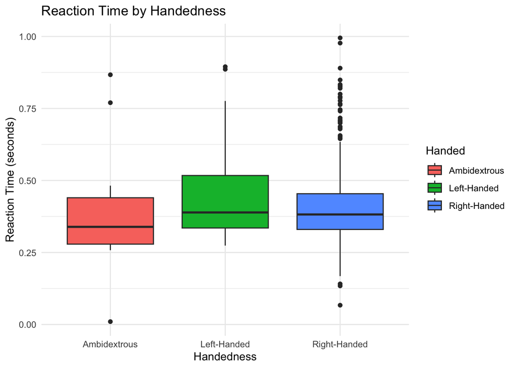

```r
ggplot(HSS2, aes(x = Handed, y = Reaction_time, fill = Handed)) +
  geom_boxplot() +
  labs(title = "Reaction Time by Handedness", x = "Handedness", y = "Reaction Time (seconds)") +
  theme_minimal()
```

The second hypothesis investigated whether reaction time differs based on handedness. The summary statistics show that ambidextrous individuals have the lowest median reaction time at **0.339 seconds**, followed by right-handed individuals at **0.382 seconds** and left-handed individuals at **0.389 seconds**. The interquartile ranges (IQRs) are as follows: ambidextrous (0.279 to 0.44 seconds), right-handed (0.33 to 0.454 seconds), and left-handed (0.335 to 0.5172 seconds). The minimum reaction times were **0.01 seconds** for ambidextrous individuals, **0.067 seconds** for right-handed individuals, and **0.274 seconds** for left-handed individuals, while the maximum reaction times were **0.867 seconds**, **0.995 seconds**, and **0.895 seconds**, respectively.

These results suggest that ambidextrous individuals tend to have faster reaction times overall, while left-handed individuals exhibit slightly slower reaction times compared to right-handed individuals. However, the overlapping IQRs indicate that many individuals within each group have similar reaction times.

### Hypothesis #3: Interaction Effect

#### Hypotheses

$$H_0: \text{There is no interaction between Gender and Handedness on
Reaction Time}$$
$$H_a: \text{There is an interaction between Gender and Handedness on
Reaction Time}$$

#### Summary Statistics

```r
interaction_summary <- HSS2 %>%
  group_by(Gender, Handed) %>%
  summarise(
    Min = min(Reaction_time, na.rm = TRUE),
    Q1 = quantile(Reaction_time, 0.25, na.rm = TRUE),
    Median = median(Reaction_time, na.rm = TRUE),
    Q3 = quantile(Reaction_time, 0.75, na.rm = TRUE),
    Max = max(Reaction_time, na.rm = TRUE)
  )
pander(interaction_summary)
```

| Gender | Handed | Min | Q1 | Median | Q3 | Max |
| --- | --- | --- | --- | --- | --- | --- |
| Female | Ambidextrous | 0.279 | 0.3215 | 0.366 | 0.461 | 0.77 |
| Female | Left-Handed | 0.302 | 0.348 | 0.442 | 0.542 | 0.895 |
| Female | Right-Handed | 0.168 | 0.3635 | 0.427 | 0.4855 | 0.995 |
| Male | Ambidextrous | 0.01 | 0.2685 | 0.3055 | 0.332 | 0.867 |
| Male | Left-Handed | 0.274 | 0.333 | 0.375 | 0.498 | 0.886 |
| Male | Right-Handed | 0.067 | 0.3093 | 0.356 | 0.414 | 0.89 |

#### Visualization

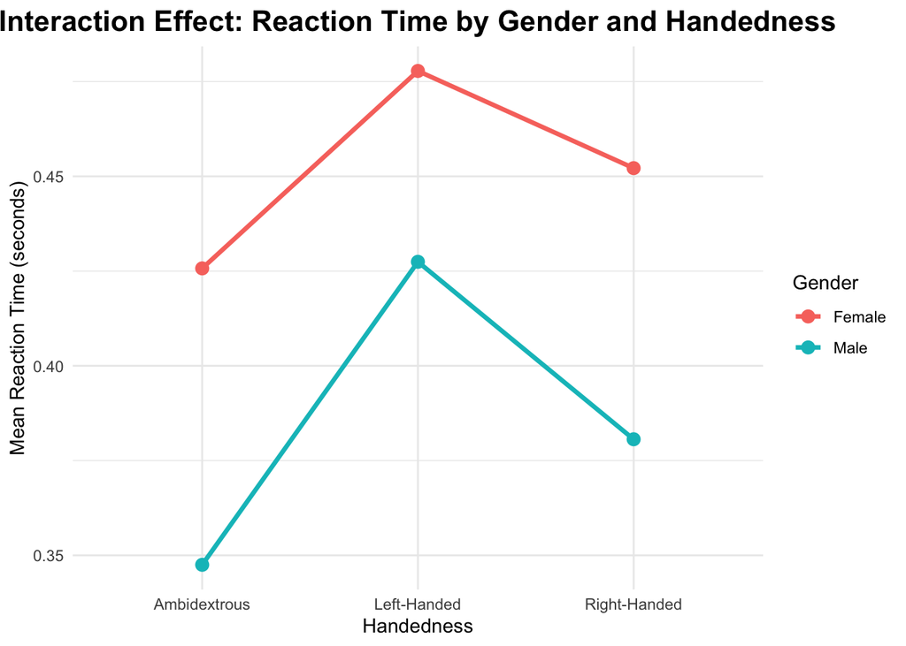

```r
interaction_summary <- HSS2 %>%
  group_by(Gender, Handed) %>%
  summarise(Mean_Reaction_time = mean(Reaction_time, na.rm = TRUE), .groups = "drop")

ggplot(interaction_summary, aes(x = Handed, y = Mean_Reaction_time, group = Gender, color = Gender)) +
  geom_line(size = 1.2) +
  geom_point(size = 3) +
  labs(title = "Interaction Effect: Reaction Time by Gender and Handedness",
       x = "Handedness",
       y = "Mean Reaction Time (seconds)") +
  theme_minimal() +
  theme(plot.title = element_text(hjust = 0.5, size = 16, face = "bold"))
```

The third hypothesis aimed to determine whether the combination of gender and handedness affects reaction time. The summary statistics reveal that male ambidextrous individuals have the lowest median reaction time at **0.3055 seconds**, followed by male right-handed individuals at **0.356 seconds** and male left-handed individuals at **0.375 seconds**. Among females, ambidextrous individuals have the lowest median reaction time at **0.366 seconds**, followed by right-handed individuals at **0.427 seconds** and left-handed individuals at **0.442 seconds**. The interquartile ranges (IQRs) vary slightly between groups, with male ambidextrous individuals showing the narrowest range (0.2685 to 0.332 seconds), indicating more consistent reaction times. In contrast, female left-handed individuals have the widest range (0.348 to 0.542 seconds), suggesting greater variability.

It looks like males exhibit faster reaction times than females across all handedness categories. Additionally, ambidextrous individuals tend to have the fastest reaction times regardless of gender.

### Two-Way ANOVA Test

```r
anova_result <- aov(Reaction_time ~ Gender * Handed, data = HSS2)
pander(summary(anova_result))
```

Analysis of Variance Model

|  | Df | Sum Sq | Mean Sq | F value | Pr(>F) |
| --- | --- | --- | --- | --- | --- |
| **Gender** | 1 | 0.5163 | 0.5163 | 27.57 | 2.366e-07 |
| **Handed** | 2 | 0.0775 | 0.03875 | 2.069 | 0.1275 |
| **Gender:Handed** | 2 | 0.005102 | 0.002551 | 0.1362 | 0.8727 |
| **Residuals** | 438 | 8.202 | 0.01873 | NA | NA |

The results of the two-way ANOVA test are summarized in the table below:

- **Gender:** The effect of gender on reaction time is statistically significant (F = 27.57, p < 0.001), indicating that males and females have significantly different reaction times.
- **Handedness:** The effect of handedness is not statistically significant (F = 2.069, p = 0.1275), suggesting that being ambidextrous, left-handed, or right-handed does not lead to significantly different reaction times.
- **Interaction (Gender × Handedness):** The interaction between gender and handedness is not statistically significant (F = 0.1362, p = 0.8727), indicating that the effect of gender on reaction time does not depend on handedness.

These results confirm that gender is the primary factor influencing reaction time, with males exhibiting faster reaction times than females. However, neither handedness nor the interaction between gender and handedness has a significant impact on reaction time.

### Assumptions

Before interpreting the results, it’s essential to check whether the assumptions of ANOVA were met.

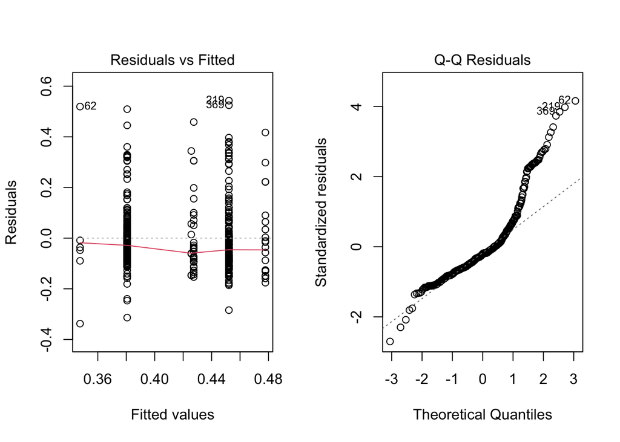

```r
par(mfrow = c(1, 2))
plot(anova_result, which = 1:2)
```

### Conclusion

This study explored the effects of gender and handedness on reaction time using a two-way ANOVA. The analysis revealed that gender significantly influences reaction time, with males exhibiting faster reaction times than females. Handedness, however, did not show a statistically significant effect, indicating that being ambidextrous, left-handed, or right-handed does not substantially impact reaction speed. Additionally, no significant interaction effect was found between gender and handedness, suggesting that the difference in reaction time between males and females is consistent regardless of handedness. Overall, the study highlights gender as a key factor affecting reaction time, while handedness plays a minimal role.